# Temperatura JP x CG

### Qual foi o inverno mais frio e o verão mais quente em JP e CG?

- - Nessa nova questão elaborada, foram criados dois gráficos semelhantes a primeira questão respondida, um referente a JP e outro a CG, a idéia é mostrar a maior e menor temperatura média, em um periodo que chamamos de inverno e verão, como inverno sendo os meses 5, 6, 7 e 8, e considerando verão como os meses 11, 12, 1 e 2 do ano.

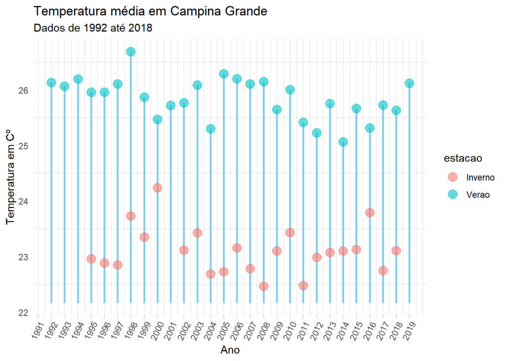

```r
cidades = climas %>%
    mutate(estacao = if_else(mes %in% 5:8, "Inverno", if_else(mes %in% c(11, 12, 1, 2), "Verao", "Outro")))%>%
    filter(estacao != "Outro" ) %>%
    group_by(estacao, ano, cidade) %>%
    summarise(temp_media = mean(tmedia))

cidades %>%
    filter(cidade == "Campina Grande" ) %>%

ggplot( aes(x=ano, y=temp_media)) +
    geom_segment(aes(xend=ano, y=min(temp_media)- 0.3, yend=temp_media), color="skyblue", size=1) +
    geom_point(aes(color=estacao), size=4, alpha=0.6) +
    theme_light() +
    theme(
        panel.grid.major.y = element_blank(),
        panel.border = element_blank(),
        axis.ticks.y = element_blank(),
        axis.text.x = element_text(angle = 65, hjust = 1)
    ) +
    labs(title="Temperatura média em Campina Grande",
         subtitle="Dados de 1992 até 2018",
         y = "Temperatura em Cº",
         x = "Ano")   +
    scale_x_continuous(breaks = 1987:2019)
```

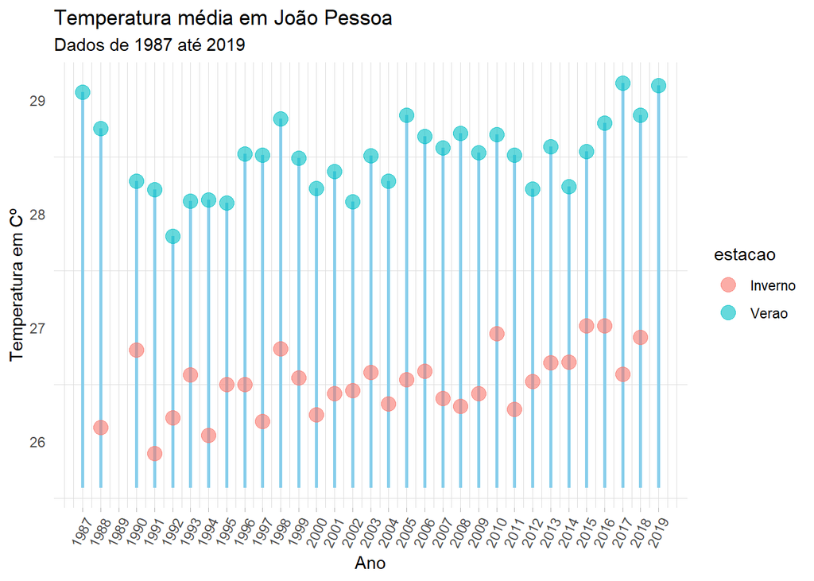

```r
cidades %>%
    filter(cidade == "João Pessoa" ) %>%

ggplot( aes(x=ano, y=temp_media)) +
    geom_segment(aes(xend=ano, y=min(temp_media)- 0.3, yend=temp_media), color="skyblue", size=1) +
    geom_point(aes(color=estacao), size=4, alpha=0.6) +
    theme_light() +
    theme(
        panel.grid.major.y = element_blank(),
        panel.border = element_blank(),
        axis.ticks.y = element_blank(),
        axis.text.x = element_text(angle = 65, hjust = 1)
    ) +
    labs(title="Temperatura média em João Pessoa",
         subtitle="Dados de 1987 até 2019",
         y = "Temperatura em Cº",
         x = "Ano")   +
    scale_x_continuous(breaks = 1987:2019)
```

Para a cidade de Campina Grande, temos o inverno mais frio em 2011 e o verão mais quente em 1998. Para João Pessoa, o inverno mais frio aconteceu em 1991, já o verão mais quente em 2017. Tais extremos são dados pelos pontos vermelhos (inverno) mais baixos e azuis (verão) mais altos nas séries de anos.